# CURA_CARLOS-PS1

## Problem Set 1, due Sunday October 15th at 11:59pm

#### Before You Start

For this problem set, you should download the flights.zip and weather.csv datasets from Canvas. Create a local copy of the notebook and rename it LASTNAME_FIRSTNAME-PS1.ipynb. Then edit your renamed file directly in your browser. You should also make sure the following libraries load correctly.

```python
# Numpy is a library for working with Arrays
import numpy as np
print ("Your numpy version: %6.6s (need at least 1.7.1)" % np.__version__)

# SciPy implements many different numerical algorithms
import scipy as sp
print ("Your SciPy version: %6.6s (need at least 0.12.0)" % sp.__version__)

# Pandas makes working with data tables easier
import pandas as pd
print ("Your Pandas version: %6.6s (need at least 0.11.0)" % pd.__version__)

# Module for plotting
import matplotlib
print ("Your Mapltolib version: %6.6s (need at least 1.2.1)" % matplotlib.__version__)

# SciKit Learn implements several Machine Learning algorithms
import sklearn
print ("Your Scikit-Learn version: %6.6s (need at least 0.13.1)" % sklearn.__version__)
```

```
Your numpy version: 1.21.5 (need at least 1.7.1)
Your SciPy version:  1.9.1 (need at least 0.12.0)
Your Pandas version:  1.4.4 (need at least 0.11.0)
Your Mapltolib version:  3.5.2 (need at least 1.2.1)
Your Scikit-Learn version:  1.0.2 (need at least 0.13.1)
```

#### Instructions:

In this problem set you will perform a basic exploratory analysis on an example dataset, bringing to bear all of your new skills in data manipulation and visualization. You will be required to submit well commented python code, documenting all code used in this problem set, along with a write up answering all questions below. Use figures as appropriate to support your answers, and when required by the problem.

This data set uses the NYCFlights13 dataset that contains information for flights originating from New York City (NYC) in 2013. You can download the dataset from flights data that you downloaded from canvas (flights.zip).

Selected questions ask you to answer in multiple ways. Make sure to provide different functions or ways for answering the same question. This will help you see that most data questions can be answered in different ways even with the same software language.

```python
import pandas as pd
import numpy as np
import matplotlib.pyplot as plt
```

```python
flights_df= pd.read_csv('flights.csv')
flights_df
```

|  | Unnamed: 0 | year | month | day | dep_time | dep_delay | arr_time | arr_delay | carrier | tailnum | flight | origin | dest | air_time | distance | hour | minute |
| --- | --- | --- | --- | --- | --- | --- | --- | --- | --- | --- | --- | --- | --- | --- | --- | --- | --- |
| 0 | 1 | 2013 | 1 | 1 | 517.0 | 2.0 | 830.0 | 11.0 | UA | N14228 | 1545 | EWR | IAH | 227.0 | 1400 | 5.0 | 17.0 |
| 1 | 2 | 2013 | 1 | 1 | 533.0 | 4.0 | 850.0 | 20.0 | UA | N24211 | 1714 | LGA | IAH | 227.0 | 1416 | 5.0 | 33.0 |
| 2 | 3 | 2013 | 1 | 1 | 542.0 | 2.0 | 923.0 | 33.0 | AA | N619AA | 1141 | JFK | MIA | 160.0 | 1089 | 5.0 | 42.0 |
| 3 | 4 | 2013 | 1 | 1 | 544.0 | -1.0 | 1004.0 | -18.0 | B6 | N804JB | 725 | JFK | BQN | 183.0 | 1576 | 5.0 | 44.0 |
| 4 | 5 | 2013 | 1 | 1 | 554.0 | -6.0 | 812.0 | -25.0 | DL | N668DN | 461 | LGA | ATL | 116.0 | 762 | 5.0 | 54.0 |
| ... | ... | ... | ... | ... | ... | ... | ... | ... | ... | ... | ... | ... | ... | ... | ... | ... | ... |
| 336771 | 336772 | 2013 | 9 | 30 | NaN | NaN | NaN | NaN | 9E | NaN | 3393 | JFK | DCA | NaN | 213 | NaN | NaN |
| 336772 | 336773 | 2013 | 9 | 30 | NaN | NaN | NaN | NaN | 9E | NaN | 3525 | LGA | SYR | NaN | 198 | NaN | NaN |
| 336773 | 336774 | 2013 | 9 | 30 | NaN | NaN | NaN | NaN | MQ | N535MQ | 3461 | LGA | BNA | NaN | 764 | NaN | NaN |
| 336774 | 336775 | 2013 | 9 | 30 | NaN | NaN | NaN | NaN | MQ | N511MQ | 3572 | LGA | CLE | NaN | 419 | NaN | NaN |
| 336775 | 336776 | 2013 | 9 | 30 | NaN | NaN | NaN | NaN | MQ | N839MQ | 3531 | LGA | RDU | NaN | 431 | NaN | NaN |

336776 rows × 17 columns

```python
# Let's start by looking at some of the structural attributes of the dataset

print (flights_df.shape)   # rows and columns
print (flights_df.columns) # column names
print (flights_df.dtypes)  # data types of each column
```

```
(336776, 17)
Index(['Unnamed: 0', 'year', 'month', 'day', 'dep_time', 'dep_delay',
       'arr_time', 'arr_delay', 'carrier', 'tailnum', 'flight', 'origin',
       'dest', 'air_time', 'distance', 'hour', 'minute'],
      dtype='object')
Unnamed: 0      int64
year            int64
month           int64
day             int64
dep_time      float64
dep_delay     float64
arr_time      float64
arr_delay     float64
carrier        object
tailnum        object
flight          int64
origin         object
dest           object
air_time      float64
distance        int64
hour          float64
minute        float64
dtype: object
```

```python
# Let's look at the unique destinations of the flights in the data

a = flights_df.dest.unique()
print(a)

# Let's now look at the top ten rows to get a sense of the data
flights_df.head(10)
```

```
['IAH' 'MIA' 'BQN' 'ATL' 'ORD' 'FLL' 'IAD' 'MCO' 'PBI' 'TPA' 'LAX' 'SFO'
 'DFW' 'BOS' 'LAS' 'MSP' 'DTW' 'RSW' 'SJU' 'PHX' 'BWI' 'CLT' 'BUF' 'DEN'
 'SNA' 'MSY' 'SLC' 'XNA' 'MKE' 'SEA' 'ROC' 'SYR' 'SRQ' 'RDU' 'CMH' 'JAX'
 'CHS' 'MEM' 'PIT' 'SAN' 'DCA' 'CLE' 'STL' 'MYR' 'JAC' 'MDW' 'HNL' 'BNA'
 'AUS' 'BTV' 'PHL' 'STT' 'EGE' 'AVL' 'PWM' 'IND' 'SAV' 'CAK' 'HOU' 'LGB'
 'DAY' 'ALB' 'BDL' 'MHT' 'MSN' 'GSO' 'CVG' 'BUR' 'RIC' 'GSP' 'GRR' 'MCI'
 'ORF' 'SAT' 'SDF' 'PDX' 'SJC' 'OMA' 'CRW' 'OAK' 'SMF' 'TUL' 'TYS' 'OKC'
 'PVD' 'DSM' 'PSE' 'BHM' 'CAE' 'HDN' 'BZN' 'MTJ' 'EYW' 'PSP' 'ACK' 'BGR'
 'ABQ' 'ILM' 'MVY' 'SBN' 'LEX' 'CHO' 'TVC' 'ANC' 'LGA']
```

|  | Unnamed: 0 | year | month | day | dep_time | dep_delay | arr_time | arr_delay | carrier | tailnum | flight | origin | dest | air_time | distance | hour | minute |
| --- | --- | --- | --- | --- | --- | --- | --- | --- | --- | --- | --- | --- | --- | --- | --- | --- | --- |
| 0 | 1 | 2013 | 1 | 1 | 517.0 | 2.0 | 830.0 | 11.0 | UA | N14228 | 1545 | EWR | IAH | 227.0 | 1400 | 5.0 | 17.0 |
| 1 | 2 | 2013 | 1 | 1 | 533.0 | 4.0 | 850.0 | 20.0 | UA | N24211 | 1714 | LGA | IAH | 227.0 | 1416 | 5.0 | 33.0 |
| 2 | 3 | 2013 | 1 | 1 | 542.0 | 2.0 | 923.0 | 33.0 | AA | N619AA | 1141 | JFK | MIA | 160.0 | 1089 | 5.0 | 42.0 |
| 3 | 4 | 2013 | 1 | 1 | 544.0 | -1.0 | 1004.0 | -18.0 | B6 | N804JB | 725 | JFK | BQN | 183.0 | 1576 | 5.0 | 44.0 |
| 4 | 5 | 2013 | 1 | 1 | 554.0 | -6.0 | 812.0 | -25.0 | DL | N668DN | 461 | LGA | ATL | 116.0 | 762 | 5.0 | 54.0 |
| 5 | 6 | 2013 | 1 | 1 | 554.0 | -4.0 | 740.0 | 12.0 | UA | N39463 | 1696 | EWR | ORD | 150.0 | 719 | 5.0 | 54.0 |
| 6 | 7 | 2013 | 1 | 1 | 555.0 | -5.0 | 913.0 | 19.0 | B6 | N516JB | 507 | EWR | FLL | 158.0 | 1065 | 5.0 | 55.0 |
| 7 | 8 | 2013 | 1 | 1 | 557.0 | -3.0 | 709.0 | -14.0 | EV | N829AS | 5708 | LGA | IAD | 53.0 | 229 | 5.0 | 57.0 |
| 8 | 9 | 2013 | 1 | 1 | 557.0 | -3.0 | 838.0 | -8.0 | B6 | N593JB | 79 | JFK | MCO | 140.0 | 944 | 5.0 | 57.0 |
| 9 | 10 | 2013 | 1 | 1 | 558.0 | -2.0 | 753.0 | 8.0 | AA | N3ALAA | 301 | LGA | ORD | 138.0 | 733 | 5.0 | 58.0 |

#### Some Tips

- This assignment involves extensive Data frame splitting and aggregation. You should look into the details of the methods groupby, transform, sum, count, mean etc.
- Many of the tasks in the assignment can be done either through the Pandas Data Frame or by converting the data frames to Series. Many of the methods in the numpy are applicable to Series only. When stuck, try to explore the type of object (Pandas Data Frame or Numpy Series) you are dealing with.

#### Question 1

Let’s explore flights from NYC to Seattle. Use the flights dataset to answer the following questions.

(a) How many flights were there from NYC airports to Seattle in 2013?

```python
# Your code here
flights_df1=flights_df[flights_df.dest=='SEA']
flightCountSeattle = flights_df1.dest.count()
flightCountSeattle
```

```
3923
```

-- Write your answer in English here --

--There are over 3923 flights that went to seattle--

--We can also assume since the dataset was from 2013 , these flights are registered under the year 2013--

(b) How many airlines fly from NYC to Seattle?

```python
airlineCountSeattle = flights_df1.origin.unique()
airlineCountSeattle
```

```
array(['EWR', 'JFK'], dtype=object)
```

(c) How many unique air planes fly (number of flights) from NYC to Seattle?

```python
# Your code here
flightCountUniqueSeattle = flights_df1.tailnum.nunique()
flightCountUniqueSeattle
```

```
935
```

-- Write your answer in English here --

--There are 935 unique flights that travel from NYC to Seattle--

(d) What is the average arrival delay for flights from NYC to Seattle?

```python
# Your code here
avgFlightDelay = flights_df1.arr_delay.mean()
avgFlightDelay
```

```
-1.0990990990990992
```

-- The average delay for flighst from NYC to Seattle is -1.09 minutes--

(e) What proportion of flights to Seattle come from each NYC airport? Provide two ways of answering the question.

```python
# Your code here
#Pandas way
flightCountSeattle

#group by origin, divide by total flights
#divide one airline flights by total flights in seattle,
#Then divide another by total flights in seattle
#count the mumber of flights that go to settle (denominator)
flightOriginSea = flights_df1.groupby(['origin']).count()
flightOriginSea / flightCountSeattle
```

| origin | Unnamed: 0 | year | month | day | dep_time | dep_delay | arr_time | arr_delay | carrier | tailnum | flight | dest | air_time | distance | hour | minute |
| --- | --- | --- | --- | --- | --- | --- | --- | --- | --- | --- | --- | --- | --- | --- | --- | --- |
| EWR | 0.466735 | 0.466735 | 0.466735 | 0.466735 | 0.464950 | 0.464950 | 0.464950 | 0.461382 | 0.466735 | 0.46546 | 0.466735 | 0.466735 | 0.461382 | 0.466735 | 0.464950 | 0.464950 |
| JFK | 0.533265 | 0.533265 | 0.533265 | 0.533265 | 0.530206 | 0.530206 | 0.529952 | 0.528932 | 0.533265 | 0.53301 | 0.533265 | 0.533265 | 0.528932 | 0.533265 | 0.530206 | 0.530206 |

```python
#For loop way
totFlightsSea = flights_df1.flight.count()
totFlightsSea

for origin in airlineCountSeattle:
    flights = len(flights_df[(flights_df['origin']==origin) & (flights_df['dest']=='SEA')].flight)
    proportion = str(flights / totFlightsSea)
    print('Flight rates from ' + origin + ' to Seattle airport are: ' + proportion )
```

```
Flight rates from EWR to Seattle airport are: 0.46673464185572267
Flight rates from JFK to Seattle airport are: 0.5332653581442773
```

-- Did the percentages in 2 ways (Pandas and For loop) in seperate code sections -- -- Each outputted 46% for EWR and 53% for JFK--

## Question 2

Flights are often delayed. Consider the following questions exploring delay patterns.

(a) Which date has the largest average departure delay? Which date has the largest average arrival delay?

```python
#Make a new column using year month and date
# Creating a Series of datetime objects
#pd.to_datetime(df[['year', 'month', 'day']])

flights_df['date'] = pd.to_datetime(flights_df[['year', 'month', 'day']])
flights_df.head()
```

|  | Unnamed: 0 | year | month | day | dep_time | dep_delay | arr_time | arr_delay | carrier | tailnum | flight | origin | dest | air_time | distance | hour | minute | date |
| --- | --- | --- | --- | --- | --- | --- | --- | --- | --- | --- | --- | --- | --- | --- | --- | --- | --- | --- |
| 0 | 1 | 2013 | 1 | 1 | 517.0 | 2.0 | 830.0 | 11.0 | UA | N14228 | 1545 | EWR | IAH | 227.0 | 1400 | 5.0 | 17.0 | 2013-01-01 |
| 1 | 2 | 2013 | 1 | 1 | 533.0 | 4.0 | 850.0 | 20.0 | UA | N24211 | 1714 | LGA | IAH | 227.0 | 1416 | 5.0 | 33.0 | 2013-01-01 |
| 2 | 3 | 2013 | 1 | 1 | 542.0 | 2.0 | 923.0 | 33.0 | AA | N619AA | 1141 | JFK | MIA | 160.0 | 1089 | 5.0 | 42.0 | 2013-01-01 |
| 3 | 4 | 2013 | 1 | 1 | 544.0 | -1.0 | 1004.0 | -18.0 | B6 | N804JB | 725 | JFK | BQN | 183.0 | 1576 | 5.0 | 44.0 | 2013-01-01 |
| 4 | 5 | 2013 | 1 | 1 | 554.0 | -6.0 | 812.0 | -25.0 | DL | N668DN | 461 | LGA | ATL | 116.0 | 762 | 5.0 | 54.0 | 2013-01-01 |

```python
flights_df2=pd.DataFrame()
flights_df2['avg_dep_delay']=flights_df.groupby('date')['dep_delay'].mean()
flights_df2['avg_arr_delay']=flights_df.groupby('date')['arr_delay'].mean()
```

```python
print(flights_df2.sort_values(by='avg_dep_delay', ascending=False))
```

```
            avg_dep_delay  avg_arr_delay
date
2013-03-08      83.536921      85.862155
2013-07-01      56.233825      58.280502
2013-09-02      53.029551      45.518430
2013-07-10      52.860702      59.626478
2013-12-05      52.327990      51.666255
...                   ...            ...
2013-09-05      -0.387797     -15.540373
2013-09-06      -0.397927     -17.895010
2013-11-09      -0.628852      -8.877980
2013-10-02      -0.919918     -13.080164
2013-09-24      -1.329832      -9.909378

[365 rows x 2 columns]
```

-- Write your answer in English here --

--The worst arrival delay date is 2013-03-08--

--The worst delay date is also 2013-03-08--

(b) Focusing on the number of delayed flights in a day, what was the worst day to fly out of NYC in 2013 if you dislike delayed flights?

```python
# Your code here
#Group by date
#group by flights that are delayed
#make a count for how many flights were delayed for each day


#flights_df2['avg_dep_delay']=flights_df.groupby('date')['dep_delay'].mean()
#take the ones greater than 0


#dep_delay_data.count()

#positive = dep_delay_data[mask]

#print(positive)


#Lambda
#print(flights_df.groupby('date')['dep_delay'].count())


flights_df2['dep_delay_Count']=flights_df.groupby('date')['dep_delay'].count()

print(flights_df2.sort_values(by='dep_delay_Count', ascending=False))
```

```
            avg_dep_delay  avg_arr_delay  dep_delay_Count
date
2013-12-02       9.021978       0.450902             1001
2013-08-05       6.715431       2.009027              998
2013-07-31       6.280843      -0.892354              997
2013-11-21       3.109328       0.212487              997
2013-08-07       8.680402       8.192153              995
...                   ...            ...              ...
2013-11-29       0.145234     -12.180303              661
2013-11-28       6.061514      -3.097792              634
2013-12-14      28.361552      46.397504              567
2013-02-08      14.855895      24.228571              458
2013-02-09      18.525773       6.639175              291

[365 rows x 3 columns]
```

(c) Are there any seasonal patterns in departure delays for flights from NYC (e.g., check monthly delay averages)?

```python
# Your code here

avgFlightDelayMonths = flights_df.groupby('month').arr_delay.mean()
```

-- Write your answer in English here --

(d) On average, how do departure delays vary over the course of a day (e.g., analyze by hour)?

```python
# Your code here
depDelayByHour = flights_df.groupby('hour').dep_delay.mean()
depDelayByHour
```

```
hour
0.0     128.642452
1.0     207.049327
2.0     239.921875
3.0     304.727273
4.0      -5.554098
5.0      -4.355644
6.0      -1.520552
7.0       0.223289
8.0       1.091432
9.0       4.268295
10.0      5.548644
11.0      5.652309
12.0      7.601892
13.0      9.380639
14.0      8.090381
15.0     10.682049
16.0     13.621150
17.0     16.756593
18.0     18.664671
19.0     21.497342
20.0     28.266213
21.0     42.064964
22.0     68.190042
23.0     96.946865
24.0     64.862069
Name: dep_delay, dtype: float64
```

-- Write your answer in English here --

--Departure delays are the worst right around midnight especiially around the 3rd hour (3am) but dies down right after then picks back up after having no delays for 3 hours after--

## Question 3

```
Which flight departing NYC in 2013 flew the fastest (e.g., calculate speed)?
```

```python
flights_df.head(10)
```

|  | Unnamed: 0 | year | month | day | dep_time | dep_delay | arr_time | arr_delay | carrier | tailnum | flight | origin | dest | air_time | distance | hour | minute | date |
| --- | --- | --- | --- | --- | --- | --- | --- | --- | --- | --- | --- | --- | --- | --- | --- | --- | --- | --- |
| 0 | 1 | 2013 | 1 | 1 | 517.0 | 2.0 | 830.0 | 11.0 | UA | N14228 | 1545 | EWR | IAH | 227.0 | 1400 | 5.0 | 17.0 | 2013-01-01 |
| 1 | 2 | 2013 | 1 | 1 | 533.0 | 4.0 | 850.0 | 20.0 | UA | N24211 | 1714 | LGA | IAH | 227.0 | 1416 | 5.0 | 33.0 | 2013-01-01 |
| 2 | 3 | 2013 | 1 | 1 | 542.0 | 2.0 | 923.0 | 33.0 | AA | N619AA | 1141 | JFK | MIA | 160.0 | 1089 | 5.0 | 42.0 | 2013-01-01 |
| 3 | 4 | 2013 | 1 | 1 | 544.0 | -1.0 | 1004.0 | -18.0 | B6 | N804JB | 725 | JFK | BQN | 183.0 | 1576 | 5.0 | 44.0 | 2013-01-01 |
| 4 | 5 | 2013 | 1 | 1 | 554.0 | -6.0 | 812.0 | -25.0 | DL | N668DN | 461 | LGA | ATL | 116.0 | 762 | 5.0 | 54.0 | 2013-01-01 |
| 5 | 6 | 2013 | 1 | 1 | 554.0 | -4.0 | 740.0 | 12.0 | UA | N39463 | 1696 | EWR | ORD | 150.0 | 719 | 5.0 | 54.0 | 2013-01-01 |
| 6 | 7 | 2013 | 1 | 1 | 555.0 | -5.0 | 913.0 | 19.0 | B6 | N516JB | 507 | EWR | FLL | 158.0 | 1065 | 5.0 | 55.0 | 2013-01-01 |
| 7 | 8 | 2013 | 1 | 1 | 557.0 | -3.0 | 709.0 | -14.0 | EV | N829AS | 5708 | LGA | IAD | 53.0 | 229 | 5.0 | 57.0 | 2013-01-01 |
| 8 | 9 | 2013 | 1 | 1 | 557.0 | -3.0 | 838.0 | -8.0 | B6 | N593JB | 79 | JFK | MCO | 140.0 | 944 | 5.0 | 57.0 | 2013-01-01 |
| 9 | 10 | 2013 | 1 | 1 | 558.0 | -2.0 | 753.0 | 8.0 | AA | N3ALAA | 301 | LGA | ORD | 138.0 | 733 | 5.0 | 58.0 | 2013-01-01 |

```python
# Your code here
#Think of how long a flight was in the air
flights_df.head(10)


#Add speed (Distance / time) = new column
flights_df['Speed'] = flights_df['distance'] / flights_df['air_time']
flights_df

#Find max speed
maxSpeed = flights_df['Speed'].max()
maxSpeed


flightMax = flights_df.iloc[flights_df['Speed'].idxmax()]
flightMax
```

```
Unnamed: 0                 216448
year                         2013
month                           5
day                            25
dep_time                   1709.0
dep_delay                     9.0
arr_time                   1923.0
arr_delay                   -14.0
carrier                        DL
tailnum                    N666DN
flight                       1499
origin                        LGA
dest                          ATL
air_time                     65.0
distance                      762
hour                         17.0
minute                        9.0
date          2013-05-25 00:00:00
Speed                   11.723077
Name: 216447, dtype: object
```

-- Write your answer in English here --

--The flight with the highest speed was flight 1499--

## Question 4

Which flights (i.e. carrier + flight + dest) happen every day? Where do they fly to?

```python
# Your code here
#Combine listed columns into one new column
#df['C'] = df['A'] + df['B']

flights_df['fullFlightDetail'] = flights_df['carrier'] + ' ' + flights_df['flight'].apply(str) + ' ' + flights_df['dest']

#Groupby and count the columns
groupedDf = flights_df.groupby('fullFlightDetail').count()

#Get flights that happen everyday (365 days)
everydayFlights = groupedDf[groupedDf['day'] >= 365]
everydayFlights
```

| fullFlightDetail | Unnamed: 0 | year | month | day | dep_time | dep_delay | arr_time | arr_delay | carrier | tailnum | flight | origin | dest | air_time | distance | hour | minute | date | Speed |
| --- | --- | --- | --- | --- | --- | --- | --- | --- | --- | --- | --- | --- | --- | --- | --- | --- | --- | --- | --- |
| AA 119 LAX | 365 | 365 | 365 | 365 | 361 | 361 | 361 | 359 | 365 | 364 | 365 | 365 | 365 | 359 | 365 | 361 | 361 | 365 | 359 |
| AA 1357 SJU | 365 | 365 | 365 | 365 | 364 | 364 | 364 | 363 | 365 | 364 | 365 | 365 | 365 | 363 | 365 | 364 | 364 | 365 | 363 |
| AA 1611 MIA | 365 | 365 | 365 | 365 | 360 | 360 | 360 | 360 | 365 | 364 | 365 | 365 | 365 | 360 | 365 | 360 | 360 | 365 | 360 |
| AA 181 LAX | 365 | 365 | 365 | 365 | 363 | 363 | 363 | 362 | 365 | 365 | 365 | 365 | 365 | 362 | 365 | 363 | 363 | 365 | 362 |
| AA 59 SFO | 365 | 365 | 365 | 365 | 359 | 359 | 359 | 359 | 365 | 363 | 365 | 365 | 365 | 359 | 365 | 359 | 359 | 365 | 359 |
| B6 1783 MCO | 365 | 365 | 365 | 365 | 365 | 365 | 365 | 365 | 365 | 365 | 365 | 365 | 365 | 365 | 365 | 365 | 365 | 365 | 365 |
| B6 219 CLT | 365 | 365 | 365 | 365 | 363 | 363 | 363 | 363 | 365 | 365 | 365 | 365 | 365 | 363 | 365 | 363 | 363 | 365 | 363 |
| B6 359 BUR | 365 | 365 | 365 | 365 | 364 | 364 | 364 | 364 | 365 | 365 | 365 | 365 | 365 | 364 | 365 | 364 | 364 | 365 | 364 |
| B6 371 FLL | 365 | 365 | 365 | 365 | 359 | 359 | 359 | 359 | 365 | 365 | 365 | 365 | 365 | 359 | 365 | 359 | 359 | 365 | 359 |
| B6 431 SRQ | 365 | 365 | 365 | 365 | 362 | 362 | 362 | 361 | 365 | 365 | 365 | 365 | 365 | 361 | 365 | 362 | 362 | 365 | 361 |
| B6 703 SJU | 365 | 365 | 365 | 365 | 364 | 364 | 364 | 364 | 365 | 365 | 365 | 365 | 365 | 364 | 365 | 364 | 364 | 365 | 364 |
| DL 2159 MCO | 365 | 365 | 365 | 365 | 364 | 364 | 364 | 364 | 365 | 365 | 365 | 365 | 365 | 364 | 365 | 364 | 364 | 365 | 364 |
| DL 2391 TPA | 365 | 365 | 365 | 365 | 360 | 360 | 360 | 359 | 365 | 365 | 365 | 365 | 365 | 359 | 365 | 360 | 360 | 365 | 359 |
| EV 5712 IAD | 365 | 365 | 365 | 365 | 351 | 351 | 351 | 351 | 365 | 365 | 365 | 365 | 365 | 351 | 365 | 351 | 351 | 365 | 351 |
| UA 15 HNL | 365 | 365 | 365 | 365 | 363 | 363 | 363 | 359 | 365 | 363 | 365 | 365 | 365 | 359 | 365 | 363 | 363 | 365 | 359 |
| VX 251 LAS | 365 | 365 | 365 | 365 | 364 | 364 | 364 | 364 | 365 | 365 | 365 | 365 | 365 | 364 | 365 | 364 | 364 | 365 | 364 |
| VX 407 LAX | 365 | 365 | 365 | 365 | 364 | 364 | 363 | 363 | 365 | 365 | 365 | 365 | 365 | 363 | 365 | 364 | 364 | 365 | 363 |
| VX 413 LAX | 365 | 365 | 365 | 365 | 362 | 362 | 362 | 360 | 365 | 365 | 365 | 365 | 365 | 360 | 365 | 362 | 362 | 365 | 360 |

-- Write your answer in English here --

--There are a total of 18 flights that happen everyday with their destinations listed in the 1st column--

## Question 5

Develop one research question you can address using the NYCFlights13 dataset. Provide two visualizations to support your exploration of this question. Discuss what you find.

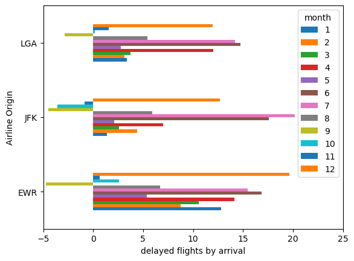

```python
# Your code here
#Worst delays by month for each airline to use for each season (Groupby origin and month)

#Arrival delay
groupedArrDelay = flights_df.groupby(['origin', 'month'])['arr_delay'].mean()
groupedArrDelay

visualOne = groupedArrDelay.unstack().plot(kind='barh')
visualOne.set_xlim(-5, 25)

visualOne.set_xlabel("delayed flights by arrival")
visualOne.set_ylabel("Airline Origin")
```

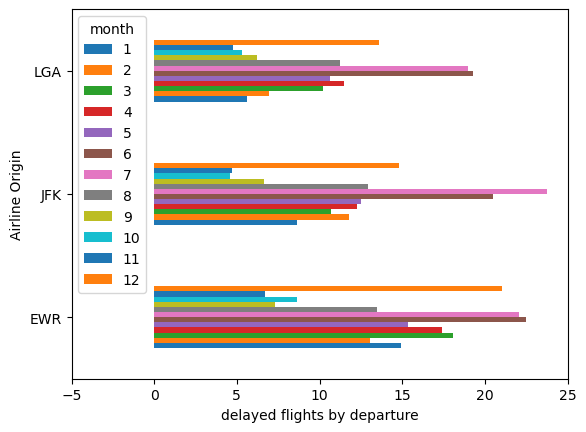

```python
#Departure delay
groupedDepDelay = flights_df.groupby(['origin', 'month'])['dep_delay'].mean()
groupedDepDelay

visualTwo = groupedDepDelay.unstack().plot(kind='barh')
visualTwo.set_xlim(-5, 25)

visualTwo.set_xlabel("delayed flights by departure")
visualTwo.set_ylabel("Airline Origin")
```

-- Enter your discussion here --

--From the first plot I divided the arribal delays by flight origin (LGA, JFK, and EWR) and we can gather that JFK had the highest arrival delays out of the 3 based on JFKs month 7 peaking the highest out of the 2 other origins highest peaks--

--From the second plot I divided the departure delays by flight origin again (LGA, JFK, and EWR) and we can gather that JFK also had the highest delays (being that it is departure) out of the 3 based on JFKs month 7 peaking the highest out of the 2 other origins highest peaks--

## Question 6

What weather conditions (weather.csv) are associated with flight delays leaving NYC? Use graphics to explore and provide an explanation.

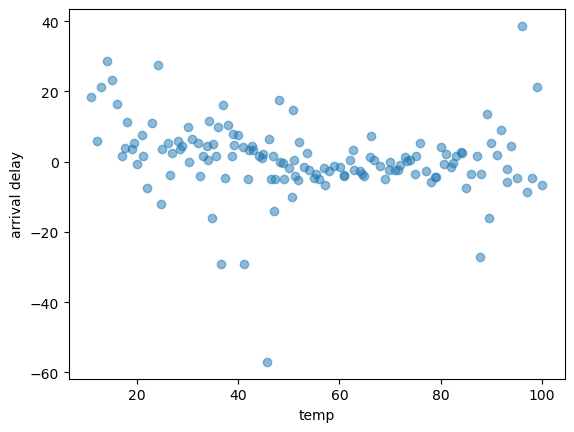

```python
# Your code here
weather_df = pd.read_csv('weather.csv')

#Merge data
df3 = pd.merge(flights_df, weather_df, on='Unnamed: 0')

#Do a temp vs arrival delay
#as_index = false will ignore the surrogate IDs
tempVsArrDelay = df3.groupby('temp', as_index = False)['arr_delay'].mean()

#plot
plot = plt.scatter(tempVsArrDelay.temp, tempVsArrDelay.arr_delay, alpha = 0.5)
plt.xlabel("temp")
plt.ylabel("arrival delay")
```

-- Enter your interpretation here --

--From the graph we can gather that flights are regularly delayed by a few minutes but as temperature gets higher or lower there are longer arrival delays that happen--

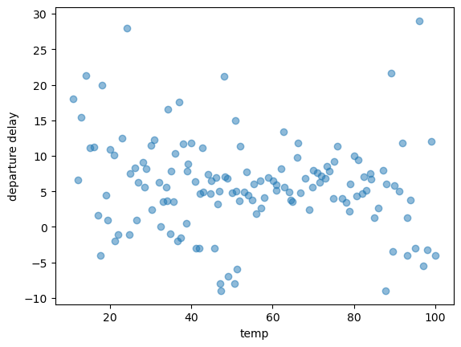

```python
tempVsDepDelay = df3.groupby('temp', as_index = False)['dep_delay'].mean()

#plot
plot = plt.scatter(tempVsDepDelay.temp, tempVsDepDelay.dep_delay, alpha = 0.5)
plt.xlabel("temp")
plt.ylabel("departure delay")
```